# Exercise 1 (20 minutes)

When you're done, assist some of the others ...

1. Download the APAD survey dataset from Absalon. Replicate the variable preparation steps as demonstrated in my slides.

```r
# 1. Load packages
pacman::p_load( # Load several R packages using the pacman package manager
  tidyverse,  # A collection of packages for data manipulation and visualization
  ggplot2,    # Powerful package for creating static, animated and interactive visualizations
  estimatr,   # Package for fast estimators for regression with weighted data
  modelr,     # Provides functions for modelling and prediction
  kableExtra, # Enhances table creation in R
  modelsummary) # Creates tables and plots to summarize statistical models
```

```r
# 2. read the APAX data
load("APAD.Rdata") # Read APAX data,
```

```r
# 3. Process APAD data
APAD <- APAD %>% mutate( # Process APAD data
  # Convert news consumption to minutes
  # Example: 2 hours and 30 minutes becomes 2*60 + 30 = 150 minutes
  news = news_hrs*60 + news_mins,
  # Create binary variable for news consumption
  news_yn = case_when(
    news < 15 ~ 0,  # 0 if less than 15 minutes
    news >= 15 ~ 1, # 1 if 15 minutes or more
    TRUE ~ as.numeric(NA)), # Handle other cases as missing
  # Calculate average discrimination index across multiple domains
  dis_index = rowMeans( # Calculate the mean for each row (participant)
    select(., # Choose specific discrimination columns from "." (APAX)
           dis_trainee, dis_job, dis_school,
           dis_house, dis_gov, dis_public),
    na.rm = TRUE), # Ignore NA values
  # Standardize discrimination index
  # scale() standardizes; as.numeric() converts to numeric vector
  z_dis_index = scale(dis_index) %>% as.numeric()
)
```

2. The APAD data contains a variable `antidiscr_law`. It asks respondents how good or bad they think it is for a country to have a law against ethnic discrimination in the workplace. The answer categories are: (1) Very bad, (2) Bad, (3) So/so, (4) Good, (5) Very good.  
   Create a scatter plot to examine whether time spent on reading news predicts more support for anti-discrimination policies. The plot should have time spent reading news on the x-axis and the `antidiscr_law` variable on the y-axis. Include a 95% confidence interval for the OLS (Ordinary Least Squares) regression line. Make sure to use weights (here called `gewFAKT`) and express weights as the size of the scattered dots.  
   Label your axes appropriately and include a title for your plot. After creating the plot, analyze your results: *What does this initial analysis suggest about the relationship between time spent reading news and support for anti-discrimination policies? Are there any limitations or potential issues with this analysis that you can identify?*

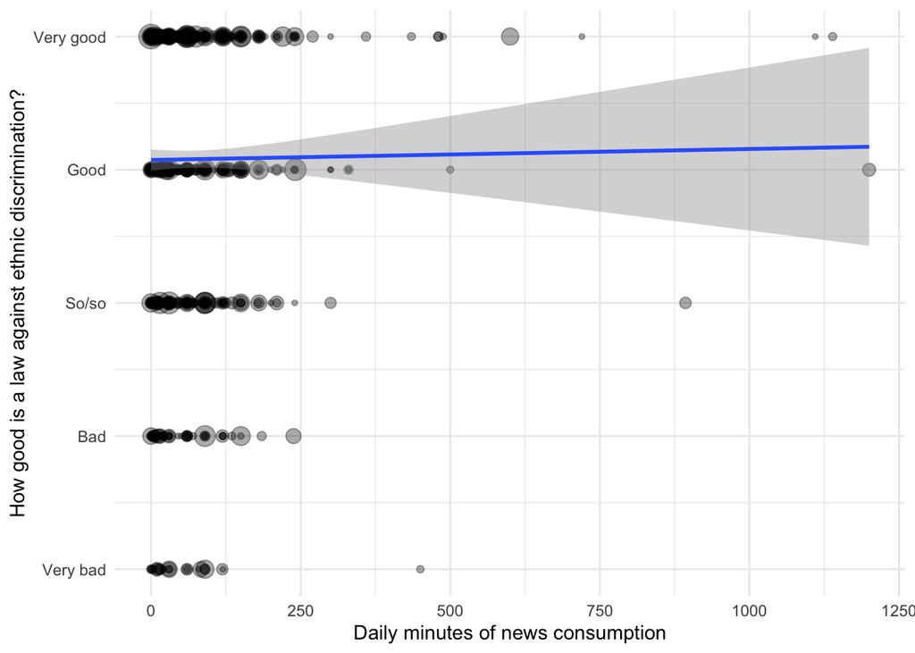

```r
# Create a ggplot object with APAD dataset
ggplot(data = APAD, aes(y = antidiscr_law, x = news)) +
  # Add scatter plot points, size based on weights, with transparency
  geom_point(aes(size = gewFAKT), alpha = 1/3) +
  # Add weighted linear regression line with confidence interval
  geom_smooth(aes(weight = gewFAKT), method = "lm") +
  # Customize y-axis to show text labels instead of numbers
  scale_y_continuous(breaks = 1:5, labels = c("Very bad", "Bad", "So/so", "Good", "Very good")) +
  # Add labels for x and y axes
  labs(y = "How good is a law against ethnic discrimination?", x = "Daily minutes of news consumption") +
  # Use a minimal theme for clean appearance
  theme_minimal() +
  # Remove the legend (for the size of points)
  theme(legend.position = "none")
```

3. Now, consider that a day has only 1440 minutes (24 hours). Some respondents may have reported unrealistic amounts of time spent reading news. To address this, recode all responses indicating more than 4 hours of daily news consumption to 4 hours. Then, create the scatter plot again using this recoded data.  
   Compare this new plot to your original one. *How does this data cleaning step affect your analysis?* What does this revised analysis suggest about the relationship between time spent reading news and support for anti-discrimination policies? Discuss any changes you observe and consider why they might have occurred.

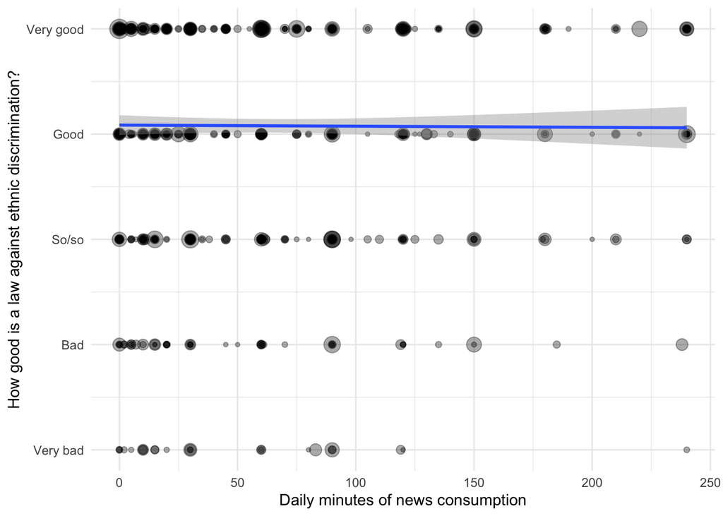

```r
# Data cleaning: Recode news consumption values
APAD <- APAD %>%
  mutate(
    news = case_when(
      # If news consumption > 240 minutes (4 hours), cap it at 240
      news > 240 ~ 240,
      # Otherwise, keep the original value
      TRUE ~ news))

# Create a ggplot object with the cleaned APAX dataset
ggplot(data = APAD, aes(y = antidiscr_law, x = news)) +
  # Add scatter plot points, size based on weights, with transparency
  geom_point(aes(size = gewFAKT), alpha = 1/3) +
  # Add weighted linear regression line with confidence interval
  geom_smooth(aes(weight = gewFAKT), method = "lm") +
  # Customize y-axis to show text labels instead of numbers
  scale_y_continuous(breaks = 1:5, labels = c("Very bad", "Bad", "So/so", "Good", "Very good")) +
  # Add labels for x and y axes
  labs(y = "How good is a law against ethnic discrimination?", x = "Daily minutes of news consumption") +
  # Use a minimal theme for clean appearance
  theme_minimal() +
  # Remove the legend (for the size of points)
  theme(legend.position = "none")
```

Interpret these results: What do the coefficient and its standard error suggest about the relationship between news consumption and support for anti-discrimination laws? How does this compare to your earlier analyses using the continuous measure of news consumption?

```r
# Run a weighted linear regression
ols <- lm_robust(antidiscr_law ~ news_yn,
                 weight = gewFAKT, data = APAD)

# Create a summary table of the regression results
modelsummary(list("Anti-discr. law" = ols), stars = TRUE,
             gof_map = c("nobs", "r.squared"), output = "kableExtra")
```

|  | Anti-discr. law |
| --- | --- |
| (Intercept) | 4.159*** |
|  | (0.125) |
| news_yn | −0.101 |
|  | (0.142) |
| Num.Obs. | 1060 |
| R2 | 0.001 |

+ p < 0.1, * p < 0.05, ** p < 0.01, *** p < 0.001